# siteOptiSample

John L. Godlee (johngodlee@gmail.com)

```r
library(siteOptiSample)

library(dplyr)
library(tidyr)
library(tibble)
library(stringr)
library(terra)
library(sf)
```

```r
library(ggplot2)
library(tidyterra)
library(scico)
library(GGally)
library(patchwork)

# Set seed
seed_val <- 9238
```

Purpose:

- To what extent are existing plots representative of the broader landscape forest structure?
- Identify optimal locations for new plots to fill gaps in multidimensional forest structure space.

```r
# Import structural metrics raster
data(san_lorenzo_rast)

# Import polygons of existing plots
data(san_lorenzo_plots)

# Import stem data from a single large plot
data(sample_stems)

# Prepare data objects
r <- unwrap(san_lorenzo_rast)
p <- san_lorenzo_plots
s <- sample_stems
```

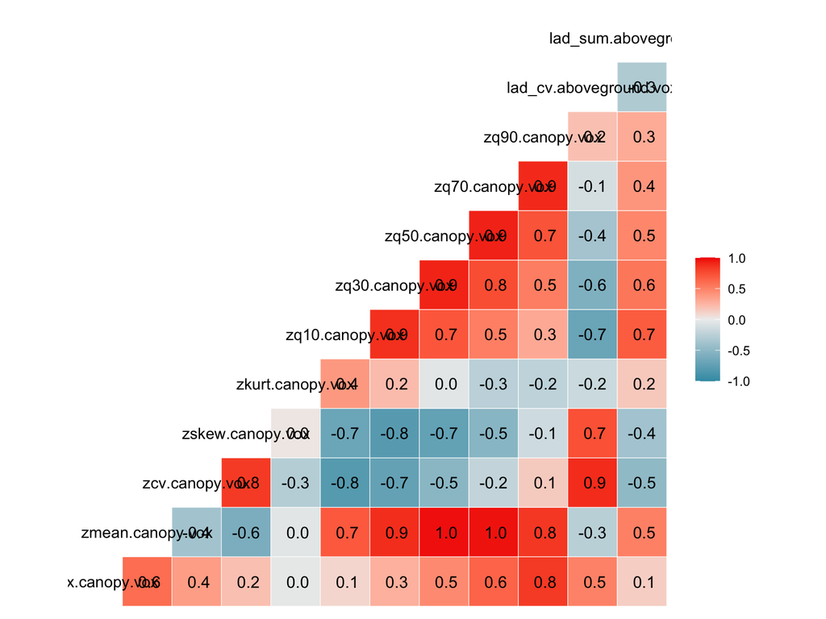

```r
# Visualize correlation among structural layers
ggcorr(as.data.frame(r), label = TRUE)
```

The structural metrics are highly correlated.

# Part 1: Assess current plot representativeness

Extract metrics from raster for each existing plot. `extractPlotMetrics()` returns a dataframe of values in the same row order as `p`.

If the structural metrics for each plot are already known, you could skip this step.

```r
old_ext <- extractPlotMetrics(r, p, fun = mean)
```

Put pixels and existing plots in the same PCA space. `PCALandscape()` returns two objects with PCA scores, one for pixels (`r_pca`) and one for plots (`p_pca`). `r_pca` is a full PCA object, while `p_pca` is only PCA scores. The PCA is run on variables scaled to unit variance shifted to center on zero. In both `r_pca` and `p_pca`, columns are PCA axes and rows are observations.

```r
old_pca <- PCALandscape(r, old_ext, center = TRUE, scale. = TRUE)
```

Calculate distance from each pixel to nearest plot in PCA space. Two methods are available: “euclidean” and “mahalanobis”. `pcaDist()` returns vector of distances for each pixel in `r_pca`.

```r
old_dist_euclidean <- pcaDist(old_pca$r_pca$x, old_pca$p_pca,
  n_pca = 3, k = 1, method = "euclidean")

old_dist_mahalanobis <- pcaDist(old_pca$r_pca$x, old_pca$p_pca,
  n_pca = 3, k = 1, method = "mahalanobis")

old_dist_list <- list(
  "euclidean" = old_dist_euclidean,
  "mahalanobis" = old_dist_mahalanobis)
```

Compare Euclidean and Mahalanobis distances:

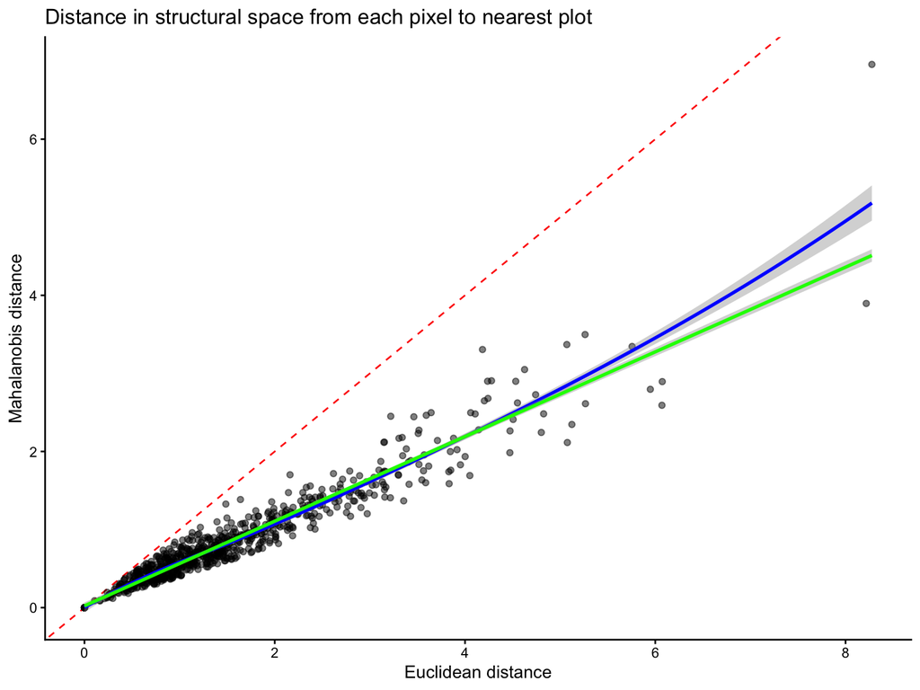

```r
data.frame(
  euclidean = c(old_dist_euclidean),
  mahalanobis = c(old_dist_mahalanobis)) %>%
  ggplot(., aes(x = euclidean, y = mahalanobis)) +
  geom_abline(linetype = 2, colour = "red") +
  geom_point(alpha = 0.5) +
  geom_smooth(colour = "blue") +
  geom_smooth(method = "lm", colour = "green") +
  theme_classic() +
  labs(
    x = "Euclidean distance",
    y = "Mahalanobis distance") +
  ggtitle("Distance in structural space from each pixel to nearest plot")
```

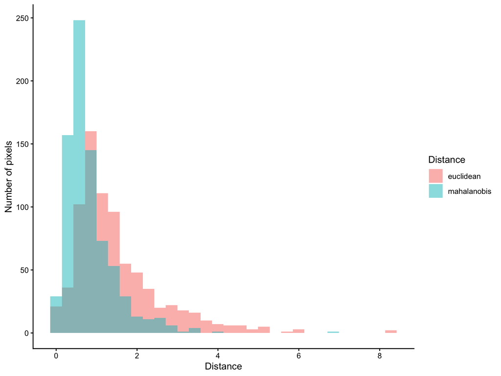

```r
data.frame(
  euclidean = c(old_dist_euclidean),
  mahalanobis = c(old_dist_mahalanobis)) %>%
  pivot_longer(everything()) %>%
  ggplot(., aes(x = value, fill = name)) +
    geom_histogram(position = "identity", alpha = 0.5) +
    scale_fill_discrete(name = "Distance") +
    theme_classic() +
    labs(
      x = "Distance",
      y = "Number of pixels")
```

`pcaDist()` can also be run using a matrix of raw variables. The contribution of individual variables to the distance metric can be weighted using the `w` argument in `pcaDist()`, which is a vector of weights for each variable, corresponding to columns in `x` and `y`:

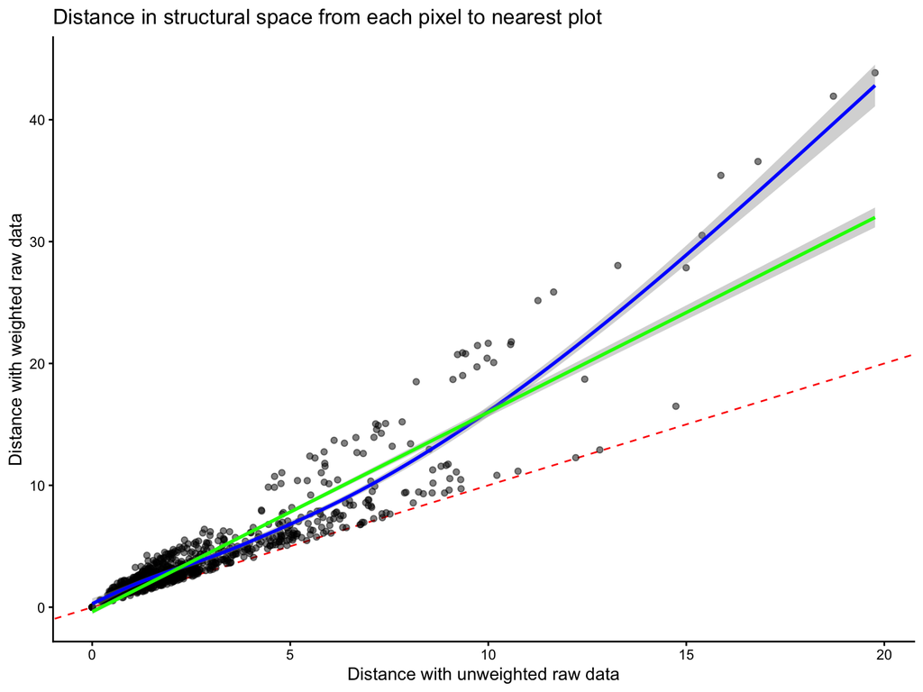

```r
# Prepare matrices with raw variables
vars_raw <- names(r)[c(1,3,5)]
r_vars_raw <- values(r)[,vars_raw]
old_ext_vars_raw <- old_ext[,vars_raw]

# Run distance function with raw variables
old_dist_raw <- pcaDist(r_vars_raw, old_ext_vars_raw,
  n_pca = 3, k = 1, method = "euclidean")

# Run distance function with weighted raw variables
old_dist_raw_weights <- pcaDist(r_vars_raw, old_ext_vars_raw, w = c(1, 5, 10),
  n_pca = 3, k = 1, method = "euclidean")

# Compare weighted and unweighted distances
data.frame(
  raw = c(old_dist_raw),
  raw_weights = c(old_dist_raw_weights)) %>%
  ggplot(., aes(x = raw, y = raw_weights)) +
  geom_abline(linetype = 2, colour = "red") +
  geom_point(alpha = 0.5) +
  geom_smooth(colour = "blue") +
  geom_smooth(method = "lm", colour = "green") +
  theme_classic() +
  labs(
    x = "Distance with unweighted raw data",
    y = "Distance with weighted raw data") +
  ggtitle("Distance in structural space from each pixel to nearest plot")
```

Create map of the dissimilarity of pixels from existing plots using both distance methods:

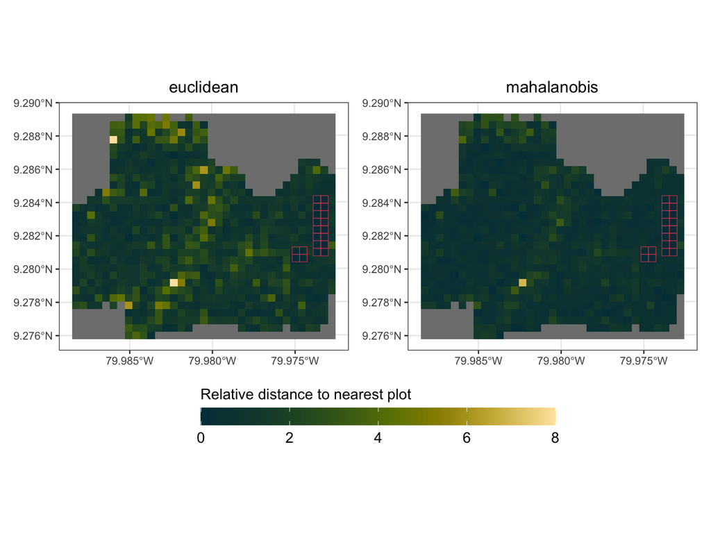

```r
# Prepare rasters with distances
old_dist_r_list <- lapply(old_dist_list, function(x) {
  out <- r[[1]]
  values(out)[!is.na(values(out))] <- x
  return(out)
})
names(old_dist_r_list) <- names(old_dist_list)

vis_map_list <- lapply(names(old_dist_r_list), function(x) {
  ggplot() +
    geom_spatraster(data = old_dist_r_list[[x]]) +
    scale_fill_scico(name = paste0("Relative distance to nearest plot"),
      palette = "bamako",
      limits = c(0, 8),
      oob = scales::squish) +
    geom_sf(data = p,
      colour = "#E74B5E", fill = NA) +
    guides(
      fill = guide_colourbar(
        title.position = "top",
        barwidth = 20,
        barheight = 1)) +
    theme_bw() +
    ggtitle(x) +
    labs(
      x = NULL,
      y = NULL) +
    theme(
      plot.title = element_text(hjust = 0.5),
      legend.position = "bottom",
      legend.title = element_text(size = 12),
      legend.text = element_text(size = 12))
})
names(vis_map_list) <- names(old_dist_r_list)

wrap_plots(vis_map_list) +
  plot_layout(
    nrow = 1,
    guides = "collect") &
  theme(legend.position = "bottom")
```

Create a PCA biplot of landscape representativeness:

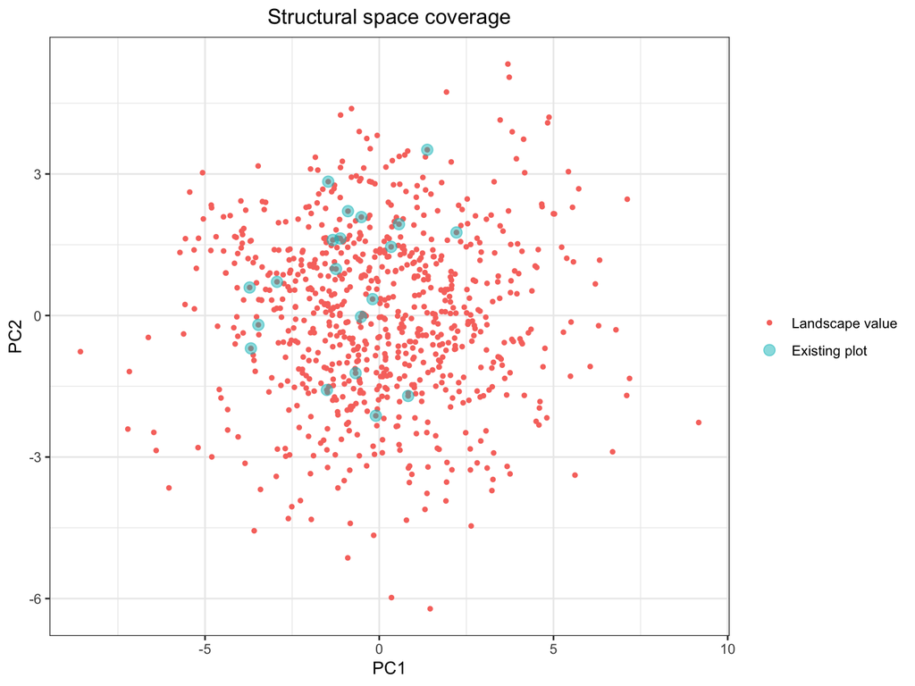

```r
# Extract PCA values from r_pca
pca_pt_r <- as.data.frame(old_pca$r_pca$x)
pca_pt_r$type <- "Landscape value"

# Extract PCA values from p_pca
pca_pt_p <- as.data.frame(old_pca$p_pca)
pca_pt_p$type <- "Existing plot"

# Combine PCA values
pca_pt_all <- rbind(pca_pt_r, pca_pt_p)
pca_pt_all$type <- factor(pca_pt_all$type,
  levels = c("Landscape value", "Existing plot"))

ggplot() +
  geom_point(data = pca_pt_all,
    aes(x = PC1, y = PC2,
      size = type, colour = type, alpha = type),
      shape = "circle") +
  scale_colour_discrete(name = NULL) +
  scale_size_manual(name = NULL,
    values = c("Landscape value" = 1, "Existing plot" = 3)) +
  scale_alpha_manual(name = NULL,
    values = c("Landscape value" = 1, "Existing plot" = 0.5)) +
  labs(x = "PC1", y = "PC2") +
  theme_bw() +
  ggtitle("Structural space coverage") +
  theme(plot.title = element_text(hjust = 0.5))
```

Classify pixels by how well-represented they are by the plots, then create a map of pixel classification. `classifRepres()` returns a dataframe with the distance of each pixel in `r_pca` from the centroid of the plots in structural space, and its classification as well-represented or poorly represented by the plots. A pixel is poorly represented if it is further from the centroid than the quantile of plot-to-centroid distances given by argument `ci`.

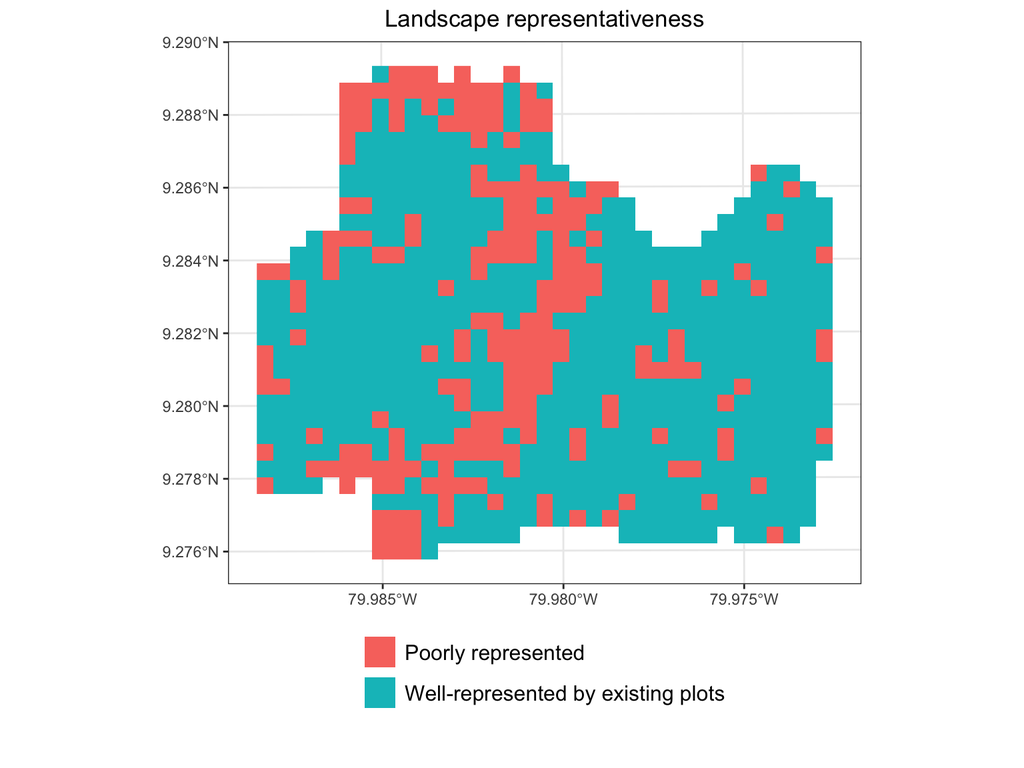

```r
# Run pixel classification
old_pca_classif <- classifRepres(
  r_pca = old_pca$r_pca$x,
  p = old_pca$p_pca,
  n_pca = 3,
  ci = 0.95
)

# Prepare raster with pixel classifications
r_classif <- r[[1]]
values(r_classif)[!is.na(values(r_classif))] <- old_pca_classif$group
r_classif_cls <- data.frame(
  id = c(1, 2),
  classif = c("Poorly represented", "Well-represented by existing plots"))
levels(r_classif) <- r_classif_cls

# Create map of pixels and their classification
ggplot() +
  geom_spatraster(data = r_classif) +
  scale_fill_discrete(name = NULL, guide = guide_legend(nrow = 3),
    na.value = NA, na.translate = FALSE) +
  theme_bw() +
  ggtitle("Landscape representativeness") +
  labs(
    x = NULL,
    y = NULL) +
  theme(
    plot.title = element_text(hjust = 0.5),
    legend.position = "bottom",
    legend.title = element_text(size = 12),
    legend.text = element_text(size = 12))
```

Create a PCA biplot of pixel classification:

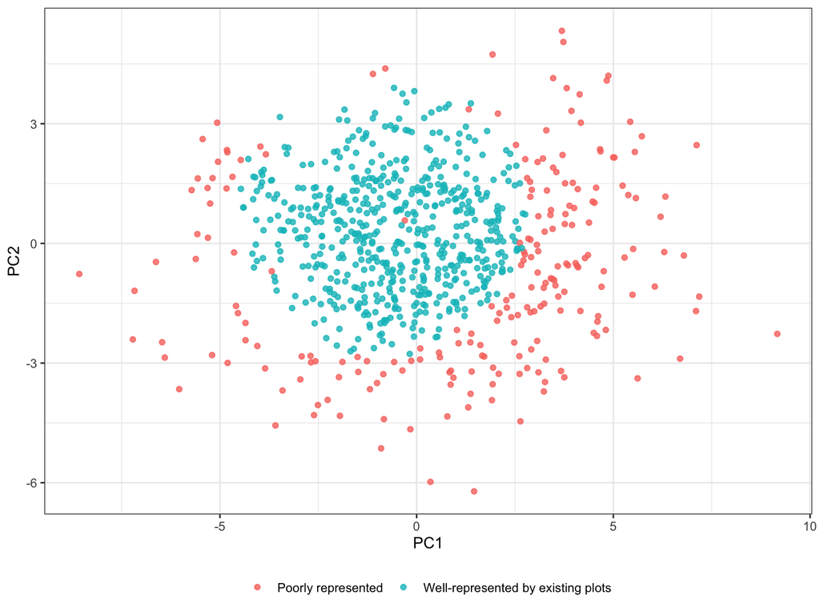

```r
old_pca_classif_df <- as.data.frame(old_pca$r_pca$x)
old_pca_classif_df$group <- old_pca_classif$group

ggplot(old_pca_classif_df, aes(PC1, PC2, colour = group)) +
  geom_point(alpha = 0.8) +
  scale_colour_discrete(name = NULL) +
  theme_bw() +
  labs(x = "PC1", y = "PC2") +
  theme(legend.position = "bottom")
```

# Part 2: Optimally locate new plots

The `plotSelect()` function optimally locates plots based on the relative distances of pixels in structural space, optionally taking into account existing plots.

These algorithms are available for locating new plots:

The `meanminSelect()` algorithm aims to minimize the mean distance of all pixels to their nearest plot in PCA space, iteratively placing new plots in pixels that most reduce the average pixel-to-nearest-plot distance. Each plot is represented by its mean structural values: existing plots by their extracted metrics, and candidate plots by the mean of the pixels within their footprint. For each candidate plot location, compute the mean pixel-to-nearest-plot distance that would result from adding a plot there, then choose the location that yields the lowest mean distance. As a result, plots concentrate in common areas structural space. Greedy selection is not guaranteed to find the best possible set of plots. Setting `refine = TRUE` adds a refinement step after greedy selection, which repeatedly swaps each new plot for the candidate location that most reduces the mean distance, until no swap improves it.

The `minimaxSelect()` algorithm aims to minimise the maximum distance between proposed plots and existing plots, iteratively placing new plots in pixels with structural attributes most dissimilar to existing plots. For each candidate plot location, compute the distance from the mean of the pixels within its footprint to the nearest plot, then choose the location with the highest distance value. Without existing plots, the first plot is placed at the location most dissimilar to the landscape mean. As a result, plots occupy structural extremes.

The `kmeansSelect()` algorithm aims to capture the structural diversity of the landscape using K-means clustering. It partitions the landscape into clusters, one per existing plot and one per proposed plot. The centroids of the existing plots’ clusters are held fixed at the existing plots’ structural values, so new clusters form in parts of structural space not already covered. It then finds the candidate plot closest to the centroid of each new cluster.

The `hypercubeSelect()` algorithm captures the landscape’s multi-dimensional structural gradient by dividing each metric into equal-probability strata, one per plot including existing plots. New plots are targeted at the strata not already occupied by existing plots, and matched to the closest available candidate plot locations. This approach ensures that proposed plots are distributed evenly across the entire range of structural conditions, representatively sampling both common and rare feature combinations.

All algorithms assess representativeness at the scale of a plot, rather than a pixel: the landscape is represented by the mean structural values within every possible plot footprint, which can be calculated with `footprintMetrics()`, and each plot is represented by its mean structural values.

The code below runs `plotSelect()` with a few different options, then compares how they affect plot placement.

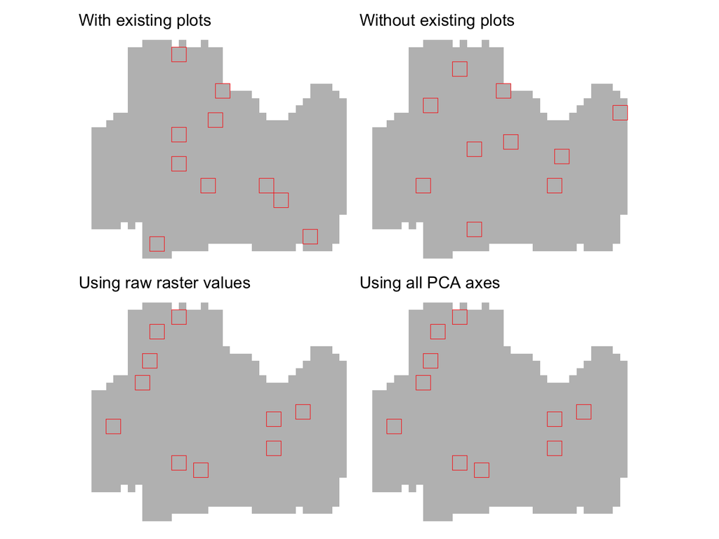

```r
# Test with existing plots
test1 <- plotSelect(
  r = r,
  p = p,
  n_plots = 10,
  p_new_dim = c(100, 100),
  r_mask = NULL,
  pca = TRUE,
  n_pca = 3,
  coord = NULL,
  method = meanminSelect
)

test1$type <- "With existing plots"

# Test without existing plots
test2 <- plotSelect(
  r = r,
  p = NULL,
  n_plots = 10,
  p_new_dim = c(100, 100),
  r_mask = NULL,
  pca = TRUE,
  n_pca = 3,
  method = meanminSelect)

test2$type <- "Without existing plots"

# Test without plots PCA
test3 <- plotSelect(
  r = r,
  p = NULL,
  n_plots = 10,
  p_new_dim = c(100, 100),
  r_mask = NULL,
  pca = FALSE,
  n_pca = NULL,
  method = meanminSelect)
test3$type <- "Using raw raster values"

# Test using all columns
test4 <- plotSelect(
  r = r,
  p = NULL,
  n_plots = 10,
  p_new_dim = c(100, 100),
  r_mask = NULL,
  pca = TRUE,
  n_pca = 12,
  method = meanminSelect)
test4$type <- "Using all PCA axes"

# Combine tests
test_1_2_3_4 <- list(
  test1,
  test2,
  test3,
  test4)

# Create a raster to use as a background
r_bg <- r[[1]]
r_bg[!is.na(values(r_bg))] <- 1
r_bg <- as.factor(r_bg)

# Compare outputs
wrap_plots(lapply(test_1_2_3_4, function(x) {
  ggplot() +
    geom_spatraster(data = r_bg, show.legend = FALSE) +
    scale_fill_manual(values = "grey", na.value = NA, na.translate = FALSE) +
    geom_sf(data = x, fill = NA, colour = "red") +
    theme_void() +
    ggtitle(unique(x$type))
}))
```

A mask layer provided by argument `r_mask` can be used to restrict the location of new plots. You could use this to filter out inaccessible locations, for example.

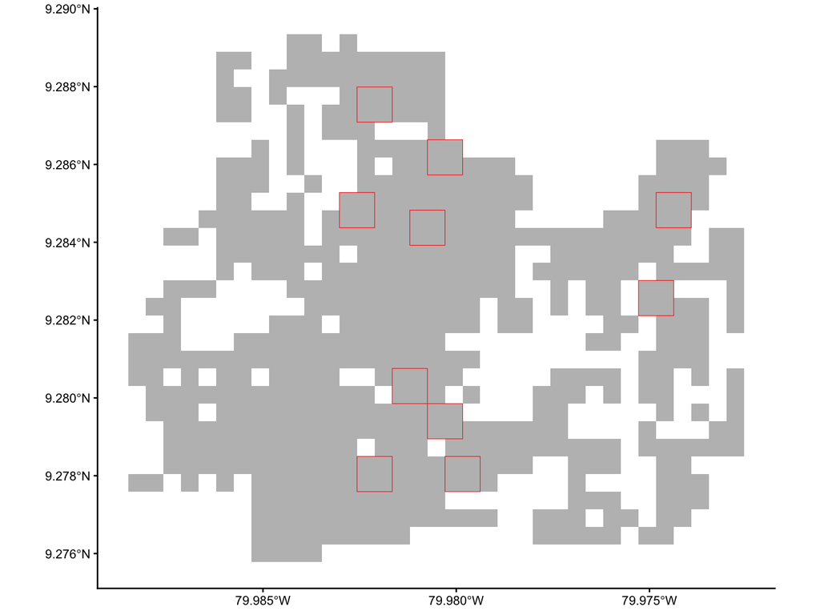

```r
# Test with mask layer
r_mask <- r[[1]]
r_mask[values(r_mask) < 35] <- NA_real_
r_mask[!is.na(values(r_mask))] <- 1
r_mask <- as.factor(r_mask)

test5 <- plotSelect(
  r = r,
  p = NULL,
  n_plots = 10,
  p_new_dim = c(100, 100),
  r_mask = r_mask,
  pca = TRUE,
  n_pca = 3,
  method = meanminSelect)
test5$type <- "Using a mask layer"

# Should always overlap mask layer
ggplot() +
  geom_spatraster(data = r_mask, show.legend = FALSE) +
  scale_fill_manual(values = "grey", na.value = NA, na.translate = FALSE) +
  geom_sf(data = test5, colour = "red", fill = NA) +
  theme_classic()
```

Comparison of the `meanminSelect()`, `minimaxSelect()`, `kmeansSelect()`, and `hypercubeSelect()` algorithms. All algorithms use the same three PCA axes. `meanminSelect()` is run twice: once with greedy selection only, and once with the optional refinement step (`refine = TRUE`), which is passed through `plotSelect()` to `meanminSelect()`.

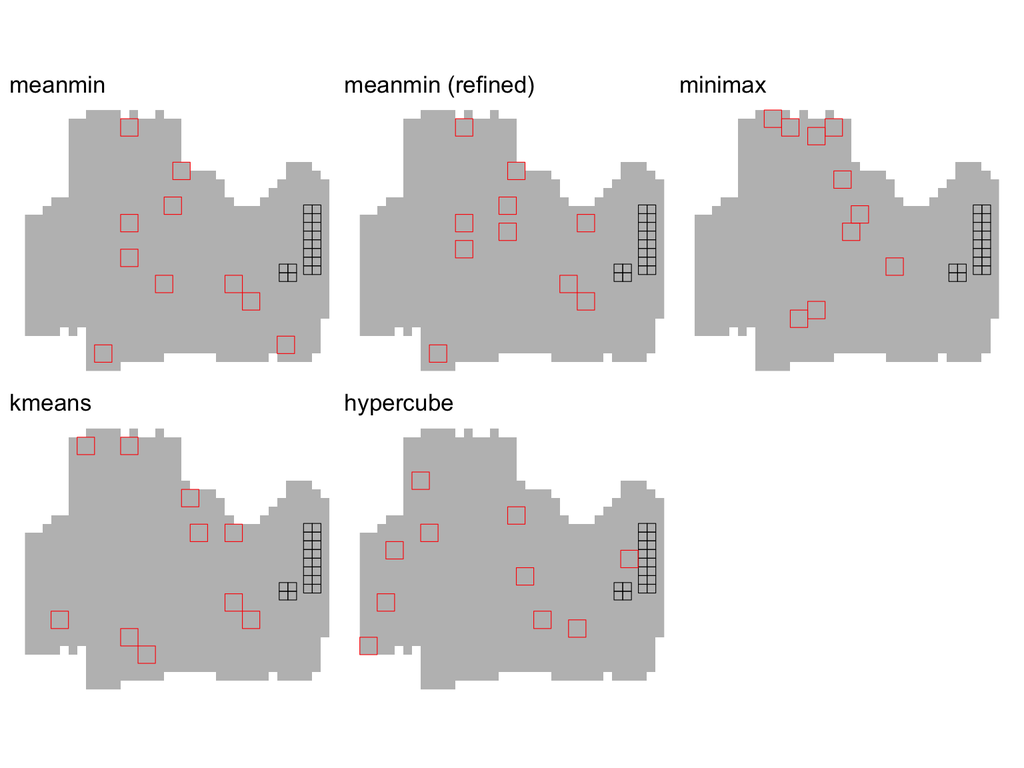

```r
# Test with refined meanmin algorithm
test9 <- plotSelect(
  r = r,
  p = p,
  n_plots = 10,
  p_new_dim = c(100, 100),
  r_mask = NULL,
  pca = TRUE,
  n_pca = 3,
  method = meanminSelect,
  refine = TRUE)
test9$type <- "meanmin (refined)"

# Test with minimax algorithm
test6 <- plotSelect(
  r = r,
  p = p,
  n_plots = 10,
  p_new_dim = c(100, 100),
  r_mask = NULL,
  pca = TRUE,
  n_pca = 3,
  method = minimaxSelect)
test6$type <- "minimax"

# Test with the kmeans algorithm
set.seed(seed_val)
test7 <- plotSelect(
  r = r,
  p = p,
  n_plots = 10,
  p_new_dim = c(100, 100),
  r_mask = NULL,
  pca = TRUE,
  n_pca = 3,
  method = kmeansSelect)
test7$type <- "kmeans"

# Test with the hypercube algorithm
set.seed(seed_val)
test8 <- plotSelect(
  r = r,
  p = p,
  n_plots = 10,
  p_new_dim = c(100, 100),
  r_mask = NULL,
  pca = TRUE,
  n_pca = 3,
  method = hypercubeSelect)
test8$type <- "hypercube"

test1$type <- "meanmin"
test_comp <- list(
  "meanmin" = test1,
  "meanmin (refined)" = test9,
  "minimax" = test6,
  "kmeans" = test7,
  "hypercube" = test8)

wrap_plots(lapply(test_comp, function(x) {
  ggplot() +
    geom_spatraster(data = r_bg, show.legend = FALSE) +
    scale_fill_manual(values = "grey", na.value = NA, na.translate = FALSE) +
    geom_sf(data = p, fill = NA, colour = "black") +
    geom_sf(data = x, fill = NA, colour = "red") +
    theme_void() +
    ggtitle(unique(x$type))
}))
```

`plotSelect()` returns the mean structural values of each new plot, in the same PCA space as the pixels and existing plots, along with diagnostics describing how representative the plots are.

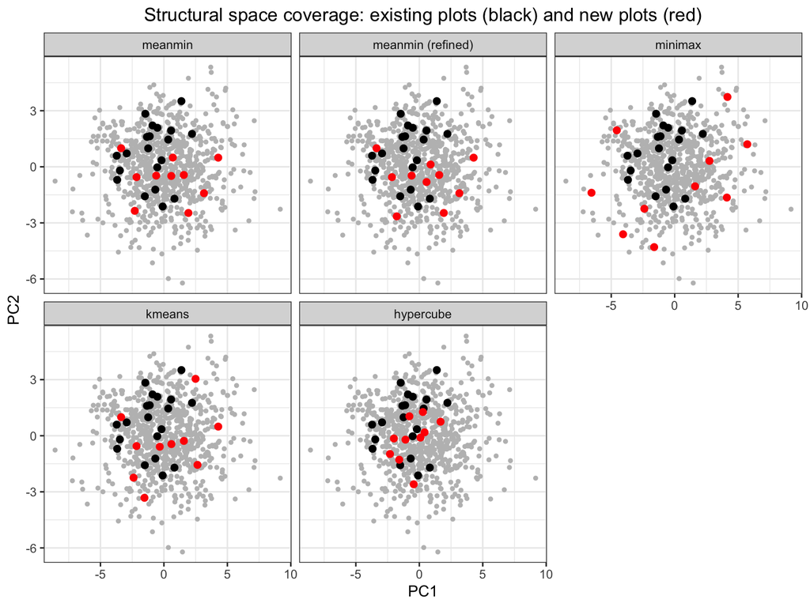

```r
# Combine PCA values of new plots from each algorithm
test_pca <- bind_rows(lapply(names(test_comp), function(x) {
  out <- st_drop_geometry(test_comp[[x]])
  out$type <- x
  out
}))
test_pca$type <- factor(test_pca$type, levels = names(test_comp))

# Landscape values and existing plots have no `type`, so they are drawn in
# every panel
ggplot() +
  geom_point(data = select(pca_pt_r, -type),
    aes(x = PC1, y = PC2), colour = "grey", size = 1) +
  geom_point(data = select(pca_pt_p, -type),
    aes(x = PC1, y = PC2), colour = "black", size = 2) +
  geom_point(data = test_pca,
    aes(x = PC1, y = PC2), colour = "red", size = 2) +
  facet_wrap(~type) +
  labs(x = "PC1", y = "PC2") +
  theme_bw() +
  ggtitle("Structural space coverage: existing plots (black) and new plots (red)") +
  theme(plot.title = element_text(hjust = 0.5))
```

The new plots are designed to complement the existing plots, so representativeness is measured as the distance from every possible 100x100 m plot location in the landscape to its nearest plot, among both the existing plots and the new plots. `meanminSelect()` aims to minimise the mean distance, while `minimaxSelect()` targets the locations furthest from any plot, so it is better judged by the upper tail of the distance distribution.

```r
# Mean metrics within every possible 100x100 m plot, projected into PCA space
fp_pca <- predict(old_pca$r_pca, footprintMetrics(r, c(100, 100)))

# Calculate distance from each possible plot to nearest plot in PCA space,
# using existing plots plus the new plots from each algorithm
dist_list <- c(
  list("Existing plots only" = pcaDist(fp_pca, old_pca$p_pca, n_pca = 3)),
  lapply(names(test_comp), function(x) {
    x_pca <- as.matrix(test_pca[test_pca$type == x, c("PC1", "PC2", "PC3")])
    pcaDist(fp_pca[,1:3], rbind(old_pca$p_pca[,1:3], x_pca), n_pca = 3)
  }))
names(dist_list)[-1] <- paste("Existing +", names(test_comp))

# Summarise distances
data.frame(
  plots = names(dist_list),
  mean = sapply(dist_list, mean),
  q95 = sapply(dist_list, stats::quantile, probs = 0.95),
  max = sapply(dist_list, max)) %>%
  knitr::kable(digits = 3, row.names = FALSE,
    col.names = c("Plots", "Mean distance", "95th percentile distance", "Maximum distance"))
```

| Plots | Mean distance | 95th percentile distance | Maximum distance |
| --- | --- | --- | --- |
| Existing plots only | 1.145 | 2.642 | 3.932 |
| Existing + meanmin | 0.746 | 1.558 | 3.538 |
| Existing + meanmin (refined) | 0.742 | 1.555 | 3.538 |
| Existing + minimax | 0.943 | 1.651 | 2.209 |
| Existing + kmeans | 0.759 | 1.472 | 3.538 |
| Existing + hypercube | 0.964 | 2.410 | 3.932 |

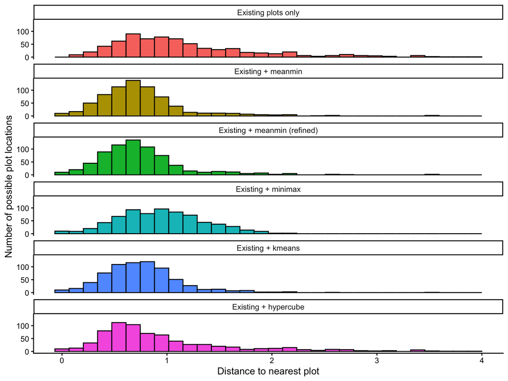

```r
# Create histograms to compare resulting distances
bind_rows(lapply(names(dist_list), function(x) {
  data.frame(name = x, value = dist_list[[x]])
})) %>%
  mutate(name = factor(name, levels = names(dist_list))) %>%
  ggplot(., aes(x = value, fill = name)) +
    geom_histogram(position = "identity", colour = "black", bins = 30) +
    facet_wrap(~name, scales = "fixed", ncol = 1) +
    theme_classic() +
    theme(legend.position = "none") +
    labs(
      x = "Distance to nearest plot",
      y = "Number of possible plot locations")
```

## How many plots are needed?

The output of `plotSelect()` includes the mean (`mean_dist`) and maximum (`max_dist`) distance from every possible plot location to its nearest plot, after adding each new plot in turn. The values before adding any new plots are stored in the `baseline` attribute. Plotting these against the number of new plots shows how representativeness improves as plots are added, and where adding more plots gives diminishing returns.

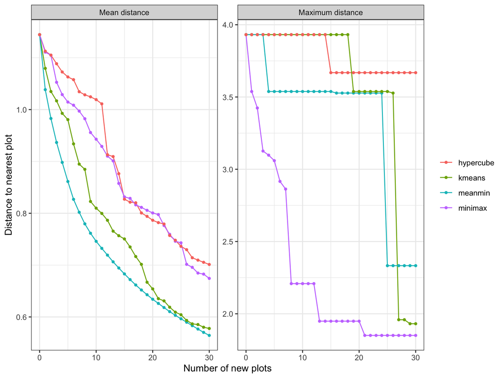

```r
# Select up to 30 plots with each algorithm
curve_methods <- list(
  "meanmin" = meanminSelect,
  "minimax" = minimaxSelect,
  "kmeans" = kmeansSelect,
  "hypercube" = hypercubeSelect)

curve_df <- bind_rows(lapply(names(curve_methods), function(x) {
  set.seed(seed_val)
  out <- plotSelect(
    r = r,
    p = p,
    n_plots = 30,
    p_new_dim = c(100, 100),
    pca = TRUE,
    n_pca = 3,
    method = curve_methods[[x]])
  baseline <- attr(out, "baseline")
  data.frame(
    method = x,
    n_new = c(0, out$plot_order),
    mean_dist = c(baseline[["mean_dist"]], out$mean_dist),
    max_dist = c(baseline[["max_dist"]], out$max_dist))
}))

curve_df %>%
  pivot_longer(c(mean_dist, max_dist)) %>%
  mutate(name = factor(name, levels = c("mean_dist", "max_dist"),
    labels = c("Mean distance", "Maximum distance"))) %>%
  ggplot(., aes(x = n_new, y = value, colour = method)) +
    geom_line() +
    geom_point(size = 1) +
    facet_wrap(~name, scales = "free_y") +
    theme_bw() +
    labs(
      x = "Number of new plots",
      y = "Distance to nearest plot",
      colour = NULL)
```

## Existing plots without locations

The locations of existing plots are not always known, or plots may lie outside the landscape, e.g. at a nearby site. If the structural metrics of each plot are known, they can be supplied instead of locations with `p_type = "values"`. `p` is then a dataframe with one row per plot and one column per structural variable, with column names matching the layers of `r`. These values should be comparable to the mean of `r` within a plot footprint, i.e. derived from the same data source and averaged over a plot-sized area.

Here, the metrics extracted earlier (`old_ext`) are used as an example. Because the plots are represented in exactly the same way, representativeness before adding new plots (the `baseline` attribute) is the same as when using plot polygons.

```r
test_vals <- plotSelect(
  r = r,
  p = as.data.frame(old_ext),
  p_type = "values",
  n_plots = 10,
  p_new_dim = c(100, 100),
  pca = TRUE,
  n_pca = 3,
  method = meanminSelect
)

rbind(
  "Plot polygons" = attr(test1, "baseline"),
  "Plot values" = attr(test_vals, "baseline")) %>%
  knitr::kable(digits = 3, col.names = c("Mean distance", "Maximum distance"))
```

|  | Mean distance | Maximum distance |
| --- | --- | --- |
| Plot polygons | 1.145 | 3.932 |
| Plot values | 1.145 | 3.932 |

The only difference is that without locations, new plots are not prevented from overlapping existing plots, and `min_dist` only applies among new plots. Here, `meanminSelect()` places new plots in parts of structural space far from existing plots, so new plots rarely fall on top of existing plots. In this case, the two sets of new plots are identical.

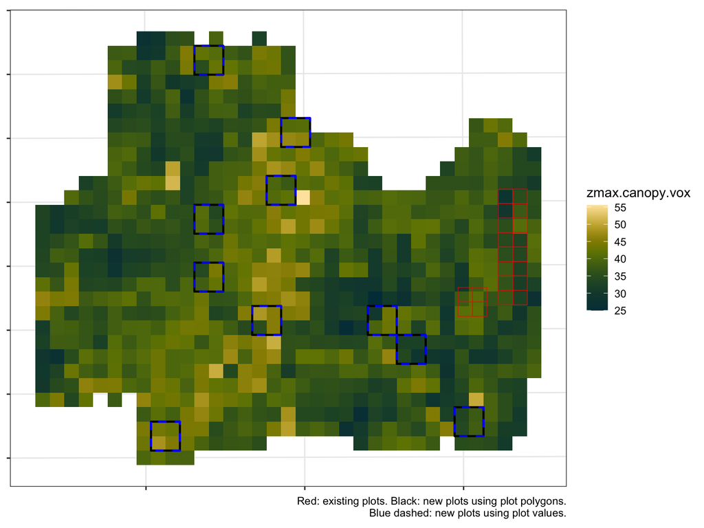

```r
ggplot() +
  geom_spatraster(data = r[[1]]) +
  scale_fill_scico(name = names(r)[1], palette = "bamako", na.value = NA) +
  geom_sf(data = p, fill = NA, colour = "red") +
  geom_sf(data = test1, fill = NA, colour = "black", linewidth = 0.8) +
  geom_sf(data = test_vals, fill = NA, colour = "blue", linetype = "dashed",
    linewidth = 0.8) +
  theme_bw() +
  theme(axis.text = element_blank()) +
  labs(caption = "Red: existing plots. Black: new plots using plot polygons.\nBlue dashed: new plots using plot values.")
```

## Field constraints

Two arguments in `plotSelect()` help to make plot locations practical in the field. `min_dist` sets the minimum distance between the edges of a new plot and any other plot, new or existing, e.g. to keep plots spatially independent. `r_cost` provides a raster describing the cost of accessing each location, e.g. travel time. When `r_cost` is supplied, each plot is placed at the cheapest location whose score is within a tolerance (`cost_tol`) of the best possible location. Larger values of `cost_tol` give more weight to cost, at the expense of representativeness.

In this example, the cost of accessing a location is the distance from the existing plots, e.g. if the field station is near the existing plots.

```r
# Distance from existing plots, in km
r_cost <- distance(r[[1]], vect(p)) / 1000
r_cost <- mask(r_cost, r[[1]])

cost_list <- lapply(c(0, 0.25, 0.5), function(x) {
  out <- plotSelect(
    r = r,
    p = p,
    n_plots = 10,
    p_new_dim = c(100, 100),
    pca = TRUE,
    n_pca = 3,
    min_dist = 100,
    r_cost = r_cost,
    cost_tol = x,
    method = meanminSelect)
  out$cost_tol <- x
  out
})

# Compare cost and representativeness
bind_rows(lapply(cost_list, st_drop_geometry)) %>%
  group_by(cost_tol) %>%
  summarise(
    mean_cost = mean(cost),
    mean_dist = last(mean_dist)) %>%
  knitr::kable(digits = 3,
    col.names = c("Cost tolerance", "Mean distance from existing plots (km)",
      "Mean distance in structural space"))
```

| Cost tolerance | Mean distance from existing plots (km) | Mean distance in structural space |
| --- | --- | --- |
| 0.00 | 0.725 | 0.747 |
| 0.25 | 0.453 | 0.766 |
| 0.50 | 0.378 | 0.780 |

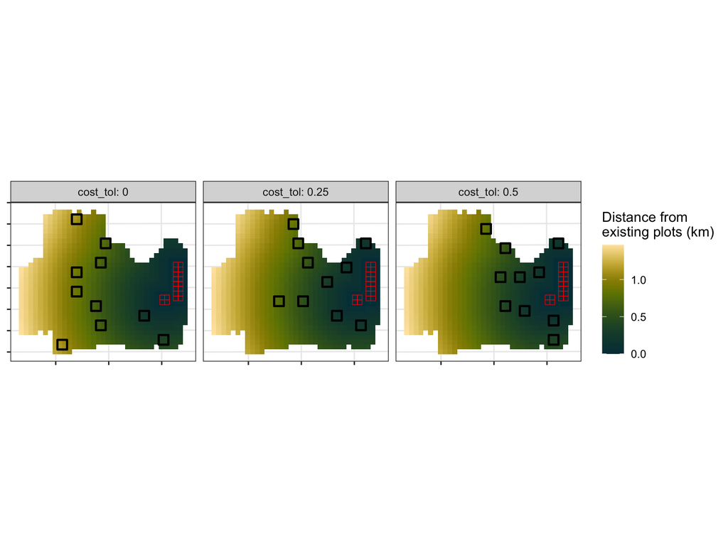

```r
ggplot() +
  geom_spatraster(data = r_cost) +
  scale_fill_scico(name = "Distance from\nexisting plots (km)", palette = "bamako",
    na.value = NA) +
  geom_sf(data = p, fill = NA, colour = "red") +
  geom_sf(data = bind_rows(cost_list), fill = NA, colour = "black", linewidth = 0.8) +
  facet_wrap(~cost_tol, labeller = label_both) +
  theme_bw() +
  theme(axis.text = element_blank())
```

## Distance metric

By default, distances in structural space are euclidean. Setting `distance = "mahalanobis"` in `plotSelect()` uses Mahalanobis distance instead, which accounts for differences in variance and correlations among the structural variables. With `pca = TRUE` this gives each retained PCA axis equal weight, rather than weighting axes by the amount of variation they explain, so it is advisable to keep only the most important axes with `n_pca`.

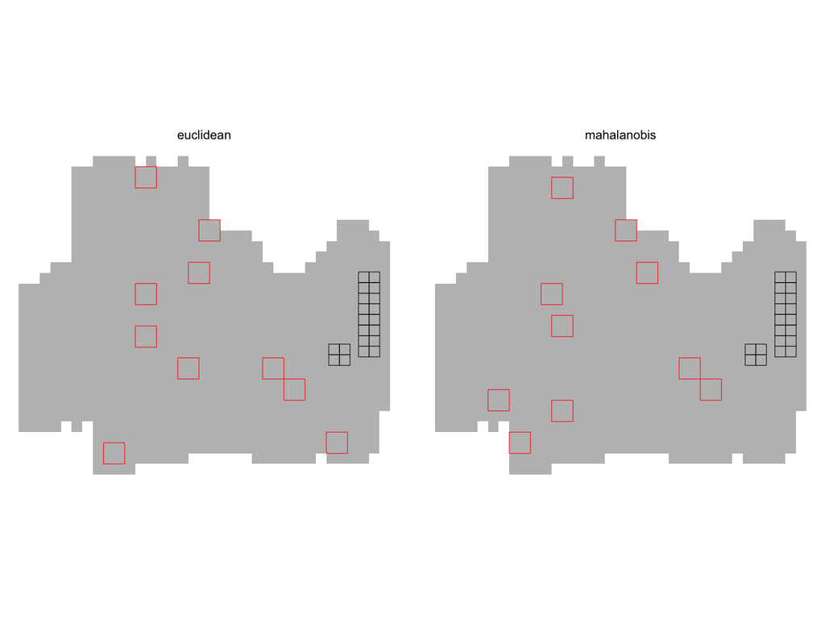

```r
dist_list_sel <- lapply(c("euclidean", "mahalanobis"), function(x) {
  out <- plotSelect(
    r = r,
    p = p,
    n_plots = 10,
    p_new_dim = c(100, 100),
    pca = TRUE,
    n_pca = 3,
    distance = x,
    method = meanminSelect)
  out$distance <- x
  out
})

ggplot() +
  geom_spatraster(data = r_bg, show.legend = FALSE) +
  scale_fill_manual(values = "grey", na.value = NA, na.translate = FALSE) +
  geom_sf(data = p, fill = NA, colour = "black") +
  geom_sf(data = bind_rows(dist_list_sel), fill = NA, colour = "red") +
  facet_wrap(~distance) +
  theme_void()
```

The two distance metrics place plots in different locations, but this does not necessarily mean that one set of plots is better. Each run of `plotSelect()` reports `mean_dist` in its own distance metric, so these values cannot be compared directly. Instead, each set of plots, together with the existing plots, is scored under both metrics, using every possible 100x100 m plot location in the landscape. Mahalanobis distance is calculated in the same way as in `plotSelect()`, using the covariance of pixels, which for PCA axes is equivalent to dividing each axis by its standard deviation.

```r
# PCA values of every possible plot location, existing plots, and the standard
# deviation of each PCA axis among pixels
fp_3 <- fp_pca[, 1:3]
p_3 <- old_pca$p_pca[, 1:3]
pc_sd <- old_pca$r_pca$sdev[1:3]

# Mean distance from every possible plot location to its nearest plot, under
# both distance metrics
scoreDist <- function(plots) {
  c(
    euclidean = mean(pcaDist(fp_3, plots, n_pca = 3)),
    mahalanobis = mean(pcaDist(
      sweep(fp_3, 2, pc_sd, "/"),
      sweep(plots, 2, pc_sd, "/"),
      n_pca = 3)))
}

dist_sel_scores <- rbind(
  scoreDist(p_3),
  t(sapply(dist_list_sel, function(x) {
    x_pca <- as.matrix(st_drop_geometry(x)[, c("PC1", "PC2", "PC3")])
    scoreDist(rbind(p_3, x_pca))
  })))

data.frame(
  plots = c("Existing plots only",
    "Existing + plots chosen with euclidean distance",
    "Existing + plots chosen with Mahalanobis distance"),
  dist_sel_scores) %>%
  knitr::kable(digits = 3, row.names = FALSE,
    col.names = c("Plots", "Mean euclidean distance", "Mean Mahalanobis distance"))
```

| Plots | Mean euclidean distance | Mean Mahalanobis distance |
| --- | --- | --- |
| Existing plots only | 1.145 | 0.650 |
| Existing + plots chosen with euclidean distance | 0.746 | 0.452 |
| Existing + plots chosen with Mahalanobis distance | 0.768 | 0.443 |

As expected, each set of plots performs best under the distance metric used to select it. The more useful comparison is how much each set loses under the other metric. Here the loss is small, a few percent, compared with the much larger improvement over the existing plots alone. This suggests that several quite different sets of plot locations represent the landscape almost equally well, and that the choice of distance metric matters less than the decision to place plots in under-represented areas of structural space.

The `classifVeg()` function can be used to classify pixels into discrete vegetation types according to their structural signature. You could then either stratify the location of new plots among these structural types by splitting the raster and then using `plotSelect()` like before, or simply use the vegetation classification as a guide to then locate new plots manually. `classifVeg()` can run two different clustering algorithms:

- K-means: Groups pixels by minimising the total variance within clusters. Tends to create spherical, roughly equal-sized clusters in PCA space.
- Gaussian Mixture Models (GMMs): Fits a mixture of multidimensional probability distributions to the data. Unlike K-means, GMM allows clusters to have different sizes, shapes, and orientations in PCA space. This makes it more effective for preserving rare outlier clusters.

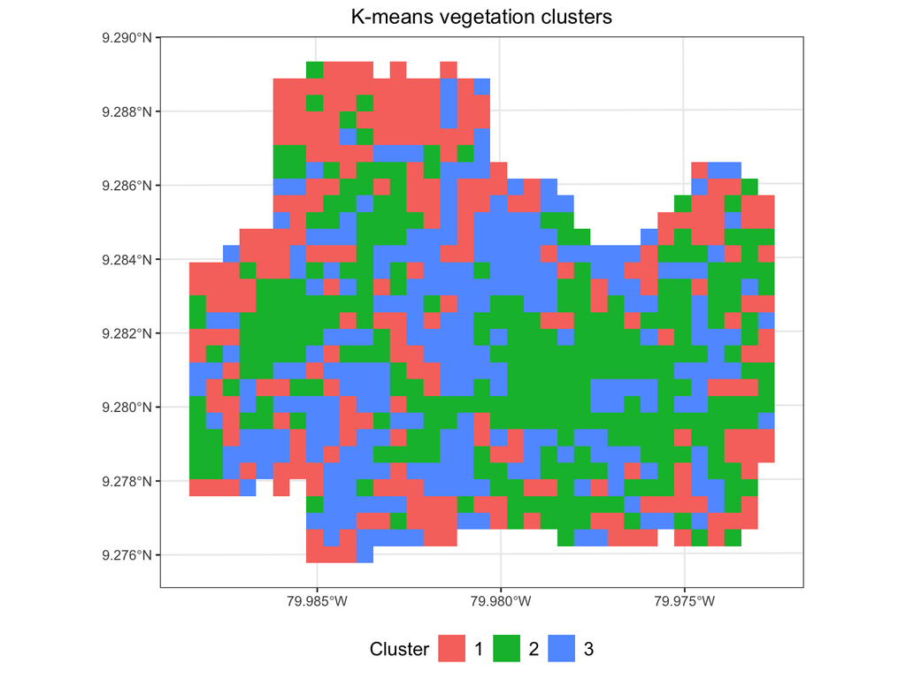

```r
# Classify according to K-means with three clusters
set.seed(seed_val)
classif_kmeans3 <- classifVeg(
  r_pca = old_pca$r_pca$x,
  k = 3,
  method = "kmeans",
  n_pca = 3,
  nstart = 25
)

# Create raster from K-means classification
r_kmeans3 <- r[[1]]
values(r_kmeans3)[!is.na(values(r_kmeans3))] <- classif_kmeans3
r_kmeans3 <- as.factor(r_kmeans3)

# Create plot
ggplot() +
  geom_spatraster(data = r_kmeans3) +
  scale_fill_discrete(name = "Cluster", na.value = NA, na.translate = FALSE) +
  theme_bw() +
  ggtitle("K-means vegetation clusters") +
  labs(
    x = NULL,
    y = NULL) +
  theme(
    plot.title = element_text(hjust = 0.5),
    legend.position = "bottom",
    legend.title = element_text(size = 12),
    legend.text = element_text(size = 12))
```

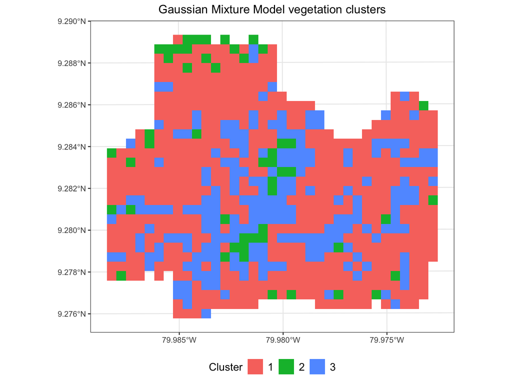

```r
# Classify according to GMM with three clusters
classif_gmm3 <- classifVeg(
  r_pca = old_pca$r_pca$x,
  k = 3,
  method = "gmm",
  n_pca = 3
)

# Create raster from GMM classification
r_gmm3 <- r[[1]]
values(r_gmm3)[!is.na(values(r_gmm3))] <- classif_gmm3
r_gmm3 <- as.factor(r_gmm3)

# Create plot
ggplot() +
  geom_spatraster(data = r_gmm3) +
  scale_fill_discrete(name = "Cluster", na.value = NA, na.translate = FALSE) +
  theme_bw() +
  ggtitle("Gaussian Mixture Model vegetation clusters") +
  labs(
    x = NULL,
    y = NULL) +
  theme(
    plot.title = element_text(hjust = 0.5),
    legend.position = "bottom",
    legend.title = element_text(size = 12),
    legend.text = element_text(size = 12))
```

```r
# Compare cluster attribution between K-means and GMM
table("Kmeans" = values(r_kmeans3), "GMM" = values(r_gmm3))
```

```
#>       GMM
#> Kmeans   1   2   3
#>      1 222  23   1
#>      2 184  17  81
#>      3 111  11 133
```

To avoid an extremely patchy mosaic of vegetation classes, it is advisable to `aggregate()` fine spatial resolution rasters to a lower resolution. You can also use the `spatial_weight` argument with spatial coordinates (`coords`) to encourage spatial clustering.

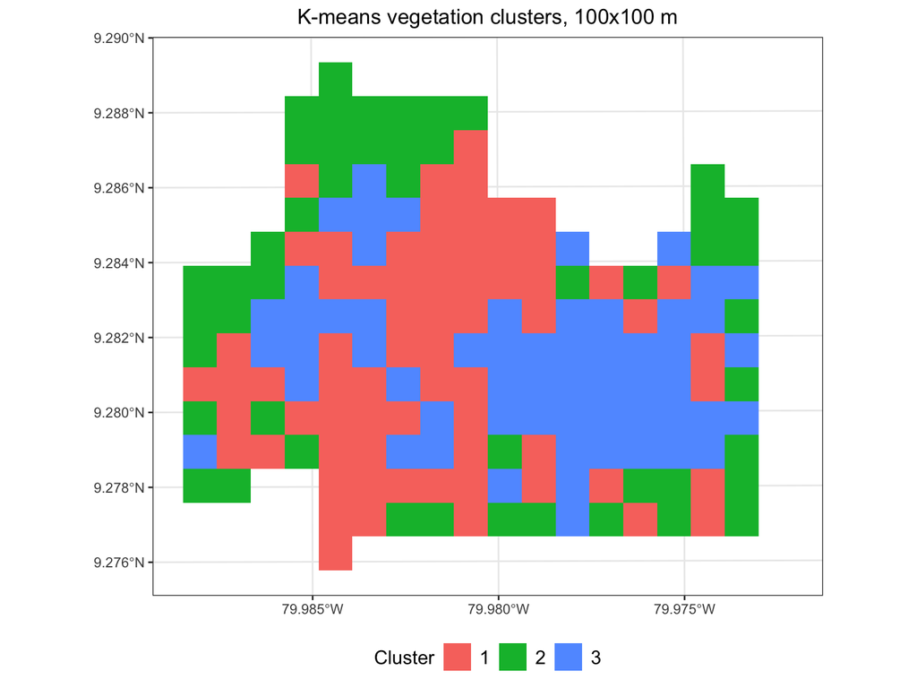

```r
# Aggregate 50x50 m raster to 100x100 m
r_agg100 <- aggregate(r, 2, fun = "mean")
r_agg100_pca <- PCALandscape(r_agg100, center = TRUE, scale. = TRUE)

# Classify according to K-means with three clusters
set.seed(seed_val)
classif_kmeans3_agg100 <- classifVeg(
  r_pca = r_agg100_pca$r_pca$x,
  k = 3,
  method = "kmeans",
  n_pca = 3,
  nstart = 25
)

# Create raster from K-means classification
r_kmeans3_agg100 <- r_agg100[[1]]
values(r_kmeans3_agg100)[complete.cases(values(r_agg100))] <- classif_kmeans3_agg100
r_kmeans3_agg100 <- as.factor(r_kmeans3_agg100)

# Create plot
ggplot() +
  geom_spatraster(data = r_kmeans3_agg100) +
  scale_fill_discrete(name = "Cluster", na.value = NA, na.translate = FALSE) +
  theme_bw() +
  ggtitle("K-means vegetation clusters, 100x100 m") +
  labs(
    x = NULL,
    y = NULL) +
  theme(
    plot.title = element_text(hjust = 0.5),
    legend.position = "bottom",
    legend.title = element_text(size = 12),
    legend.text = element_text(size = 12))
```

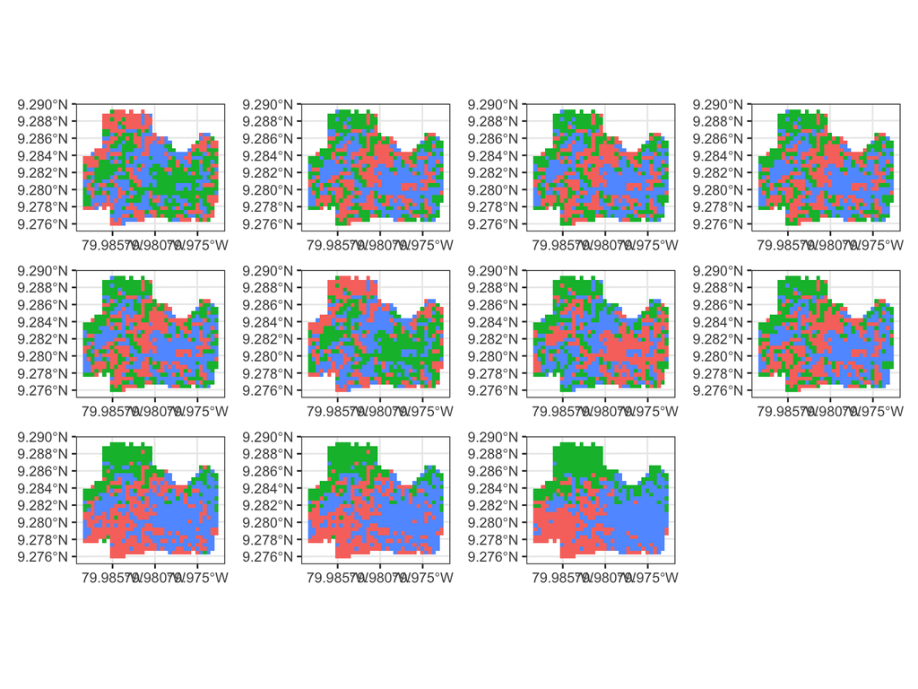

```r
coord_df <- crds(r, na.rm = TRUE)

classif_gmm_spwt_list <- lapply(seq(0, 1, 0.1), function(x) {
  set.seed(seed_val)
  classif <- classifVeg(
    r_pca = old_pca$r_pca$x,
    k = 3,
    method = "kmeans",
    n_pca = 3,
    spatial_weight = x,
    coords = coord_df,
  )

  r_classif <- r[[1]]
  values(r_classif)[!is.na(values(r_classif))] <- classif
  r_classif <- as.factor(r_classif)

  return(r_classif)
})

wrap_plots(lapply(classif_gmm_spwt_list, function(x) {
  ggplot() +
    geom_spatraster(data = x) +
    scale_fill_discrete(name = "Cluster", na.value = NA, na.translate = FALSE) +
    theme_bw() +
    labs(
      x = NULL,
      y = NULL) +
    theme(
      plot.title = element_text(hjust = 0.5),
      legend.position = "bottom",
      legend.title = element_text(size = 12),
      legend.text = element_text(size = 12))
})) +
  plot_layout(guides = "collect", axes = "collect") &
  theme(legend.position = "none")
```

# Part 3: Spatial data as a matrix

`plotSelect()`, `PCALandscape()`, `meanminSelect()`, `minimaxSelect()`, `kmeansSelect()`, and `hypercubeSelect()` also work with spatial data as a dataframe or matrix.

```r
# Extract structural metrics as a non-spatial matrix
r_df <- values(r)
valid_rows <- complete.cases(r_df)
r_df <- r_df[valid_rows,]
r_coord <- crds(r)
r_df_all <- cbind(r_df, r_coord)

# Extract existing plots as row indices in r_df
p_vect <- vect(p)
p_vect <- project(p_vect, crs(r))
r_cov <- cells(r, p_vect)[,"cell"]
p_ind <- match(r_cov, which(valid_rows))
p_ind <- p_ind[!is.na(p_ind)]
```

`PCALandscape()` returns identical values whether using a `SpatRaster` or matrix for argument `r`:

```r
all(PCALandscape(r_df, old_ext, center = TRUE, scale. = TRUE)$r_pca$x == old_pca$r_pca$x)
```

```
#> [1] TRUE
```

`plotSelect()` gives similar results using either a raster or a dataframe of structural metrics. When `r` is a dataframe, the function returns indices of the selected rows from the dataframe of structural metrics.

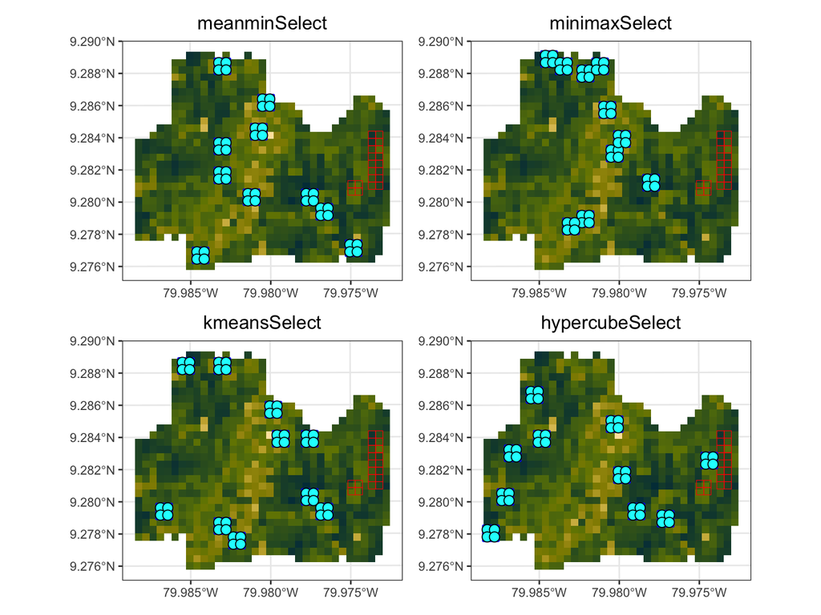

```r
test_df1 <- plotSelect(
  r = r_df_all,
  p = p,
  n_plots = 10,
  p_new_dim = c(100, 100),
  r_mask = NULL,
  pca = TRUE,
  n_pca = 3,
  coord = c("x", "y"),
  method = meanminSelect
)
test_df1_coord <- as.data.frame(r_coord[test_df1,])

test_r1 <- plotSelect(
  r = r,
  p = p,
  n_plots = 10,
  p_new_dim = c(100, 100),
  r_mask = NULL,
  pca = TRUE,
  n_pca = 3,
  method = meanminSelect
)

test_df2 <- plotSelect(
  r = r_df_all,
  p = p,
  n_plots = 10,
  p_new_dim = c(100, 100),
  r_mask = NULL,
  pca = TRUE,
  n_pca = 3,
  coord = c("x", "y"),
  method = minimaxSelect
)
test_df2_coord <- as.data.frame(r_coord[test_df2,])

test_r2 <- plotSelect(
  r = r,
  p = p,
  n_plots = 10,
  p_new_dim = c(100, 100),
  r_mask = NULL,
  pca = TRUE,
  n_pca = 3,
  method = minimaxSelect
)

set.seed(seed_val)  # Set identical seed to ensure identical results
test_df3 <- plotSelect(
  r = r_df_all,
  p = p,
  n_plots = 10,
  p_new_dim = c(100, 100),
  r_mask = NULL,
  pca = TRUE,
  n_pca = 3,
  coord = c("x", "y"),
  method = kmeansSelect
)
test_df3_coord <- as.data.frame(r_coord[test_df3,])

set.seed(seed_val)  # Set identical seed to ensure identical results
test_r3 <- plotSelect(
  r = r,
  p = p,
  n_plots = 10,
  p_new_dim = c(100, 100),
  r_mask = NULL,
  pca = TRUE,
  n_pca = 3,
  method = kmeansSelect
)

set.seed(seed_val)  # Set identical seed to ensure identical results
test_df4 <- plotSelect(
  r = r_df_all,
  p = p,
  n_plots = 10,
  p_new_dim = c(100, 100),
  r_mask = NULL,
  pca = TRUE,
  n_pca = 3,
  coord = c("x", "y"),
  method = hypercubeSelect
)
test_df4_coord <- as.data.frame(r_coord[test_df4,])

set.seed(seed_val)  # Set identical seed to ensure identical results
test_r4 <- plotSelect(
  r = r,
  p = p,
  n_plots = 10,
  p_new_dim = c(100, 100),
  r_mask = NULL,
  pca = TRUE,
  n_pca = 3,
  method = hypercubeSelect
)

p_df_r1 <- ggplot() +
  geom_spatraster(data = r[[1]]) +
  scale_fill_scico(name = "Canopy height (zmax)", palette = "bamako",
    na.value = NA) +
  geom_sf(data = p, fill = NA, colour = "red") +
  geom_sf(data = test_r1, fill = NA, colour = "blue", linewidth = 1) +
  geom_point(data = test_df1_coord, aes(x = x, y = y ), shape = 21, colour = "black", fill = "cyan", size = 3) +
  theme_bw() +
  ggtitle("meanminSelect") +
  labs(
    x = NULL,
    y = NULL) +
  theme(
    plot.title = element_text(hjust = 0.5),
    legend.position = "none",
    legend.title = element_text(size = 12),
    legend.text = element_text(size = 12))

p_df_r2 <- ggplot() +
  geom_spatraster(data = r[[1]]) +
  scale_fill_scico(name = "Canopy height (zmax)", palette = "bamako",
    na.value = NA) +
  geom_sf(data = p, fill = NA, colour = "red") +
  geom_sf(data = test_r2, fill = NA, colour = "blue", linewidth = 1) +
  geom_point(data = test_df2_coord, aes(x = x, y = y ), shape = 21, colour = "black", fill = "cyan", size = 3) +
  theme_bw() +
  ggtitle("minimaxSelect") +
  labs(
    x = NULL,
    y = NULL) +
  theme(
    plot.title = element_text(hjust = 0.5),
    legend.position = "none",
    legend.title = element_text(size = 12),
    legend.text = element_text(size = 12))

p_df_r3 <- ggplot() +
  geom_spatraster(data = r[[1]]) +
  scale_fill_scico(name = "Canopy height (zmax)", palette = "bamako",
    na.value = NA) +
  geom_sf(data = p, fill = NA, colour = "red") +
  geom_sf(data = test_r3, fill = NA, colour = "blue", linewidth = 1) +
  geom_point(data = test_df3_coord, aes(x = x, y = y ), shape = 21, colour = "black", fill = "cyan", size = 3) +
  theme_bw() +
  ggtitle("kmeansSelect") +
  labs(
    x = NULL,
    y = NULL) +
  theme(
    plot.title = element_text(hjust = 0.5),
    legend.position = "none",
    legend.title = element_text(size = 12),
    legend.text = element_text(size = 12))

p_df_r4 <- ggplot() +
  geom_spatraster(data = r[[1]]) +
  scale_fill_scico(name = "Canopy height (zmax)", palette = "bamako",
    na.value = NA) +
  geom_sf(data = p, fill = NA, colour = "red") +
  geom_sf(data = test_r4, fill = NA, colour = "blue", linewidth = 1) +
  geom_point(data = test_df4_coord, aes(x = x, y = y ), shape = 21, colour = "black", fill = "cyan", size = 3) +
  theme_bw() +
  ggtitle("hypercubeSelect") +
  labs(
    x = NULL,
    y = NULL) +
  theme(
    plot.title = element_text(hjust = 0.5),
    legend.position = "none",
    legend.title = element_text(size = 12),
    legend.text = element_text(size = 12))

wrap_plots(p_df_r1, p_df_r2, p_df_r3, p_df_r4) +
  plot_layout(
    nrow = 2,
    guides = "collect")
```

`plotSelect()` also has argument `het_q`, a numeric value between 0 and 1 defining a threshold to filter out internally heterogeneous candidate plot locations. This prevents plots being placed on sharp structural transitions. `het_q` represents the maximum quantile for the total focal standard deviation of metrics within candidate plot footprint, e.g. 0.8 excludes the top 20% most heterogeneous areas.

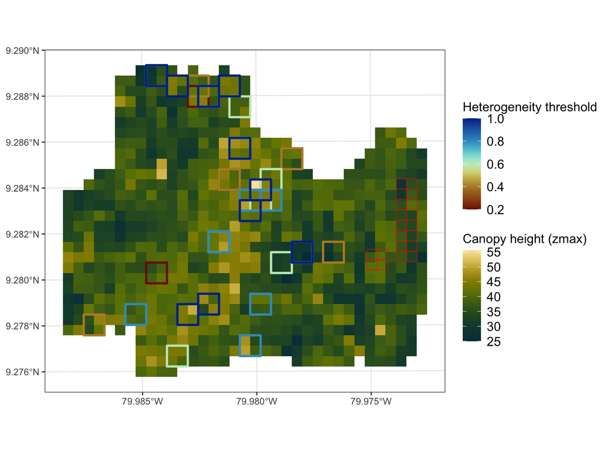

```r
het_q_list <- lapply(seq(0.2, 1, 0.2), function(x) {
  out <- plotSelect(
    r = r,
    p = p,
    n_plots = 10,
    p_new_dim = c(100, 100),
    r_mask = NULL,
    pca = TRUE,
    n_pca = 3,
    het_q = x,
    method = minimaxSelect
  )
  out$het_q <- x
  out
})

het_q_poly <- bind_rows(het_q_list)

ggplot() +
  geom_spatraster(data = r[[1]]) +
  scale_fill_scico(name = "Canopy height (zmax)", palette = "bamako",
    na.value = NA) +
  geom_sf(data = p, fill = NA, colour = "red") +
  geom_sf(data = het_q_poly, aes(colour = het_q), fill = NA, linewidth = 1) +
  scale_colour_scico(name = "Heterogeneity threshold", palette = "roma") +
  theme_bw() +
  labs(
    x = NULL,
    y = NULL) +
  theme(
    plot.title = element_text(hjust = 0.5),
    legend.title = element_text(size = 12),
    legend.text = element_text(size = 12))
```

# Part 4: Selecting 1 ha TLS plots based on stem size distribution

This additional code is somewhat separate to the main package, but is included here to document one approach for selecting 100x100 m (1 ha) TLS plots for GEO-TREES sites.

In GEO-TREES, TLS plots should sample a range of stem sizes and forest composition. We first divide the plot into three habitat types. We then pick one plot which represents each habitat. We assume that in old-growth tropical forest any 1 ha chunk will include sufficient numbers of small stems, so we focus on sampling the large rare individuals that are responsible for the most biomass.

In this example, a dataframe of stem measurements is provided for one large ForestGEO style plot. Each stem has a diameter measurement and XY stem map coordinates. The plot is 400x400 m (16 ha) and is divided into 20x20 m quadrats. We will use the 20x20 m quadrats to align 100x100 m (1 ha) TLS subplots.

```r
# Load additional packages
library(vegan)
library(cluster)
```

First determine the habitat types. The code below shows two different clustering methods: hierarchical clustering `hclust()` using the “ward.D2” algorithm, and partitioning around medoids using `cluster::pam()`. We subset the stem data to only stems larger than 10 cm diameter.

```r
# Subset to stems >= 10 cm diameter.
# Calculate the basal area of each stem.
# Extract row and column of each 20x20 m quadrat.
s_ge10 <- s %>%
  filter(diam >= 10) %>%
  mutate(
    ba = pi * (diam / 2)^2,
    col = as.numeric(str_sub(quadrat, 1, 2)),
    row = as.numeric(str_sub(quadrat, 3, 4)))

# Create a community matrix. Basal area per species (columns) within each quadrat (rows)
s_agg <- aggregate(ba ~ quadrat + species, data = s_ge10, FUN = sum)
mat <- as.data.frame.matrix(xtabs(ba ~ quadrat + species, data = s_agg))

# Hellinger transformation of community matrix
# Bray-Curtis dissimilarity matrix
mat_hell <- decostand(mat, method = "hellinger")
dist_bc <- vegdist(mat_hell, method = "bray")

# Hierarchical clustering method
hc <- hclust(dist_bc, method = "ward.D2")
hc_clust <- cutree(hc, k = 3)

# Partitioning around medoids method
bc_pam <- pam(dist_bc, k = 3)
pam_clust <- bc_pam$clustering
```

Compare the two clustering approaches:

```r
# Compare the two clustering approaches
stopifnot(all(names(hc_clust) == names(pam_clust)))
table(hc_clust, pam_clust)
```

```
#>         pam_clust
#> hc_clust   1   2   3
#>        1  75  21   2
#>        2   1  13  72
#>        3 105  84  27
```

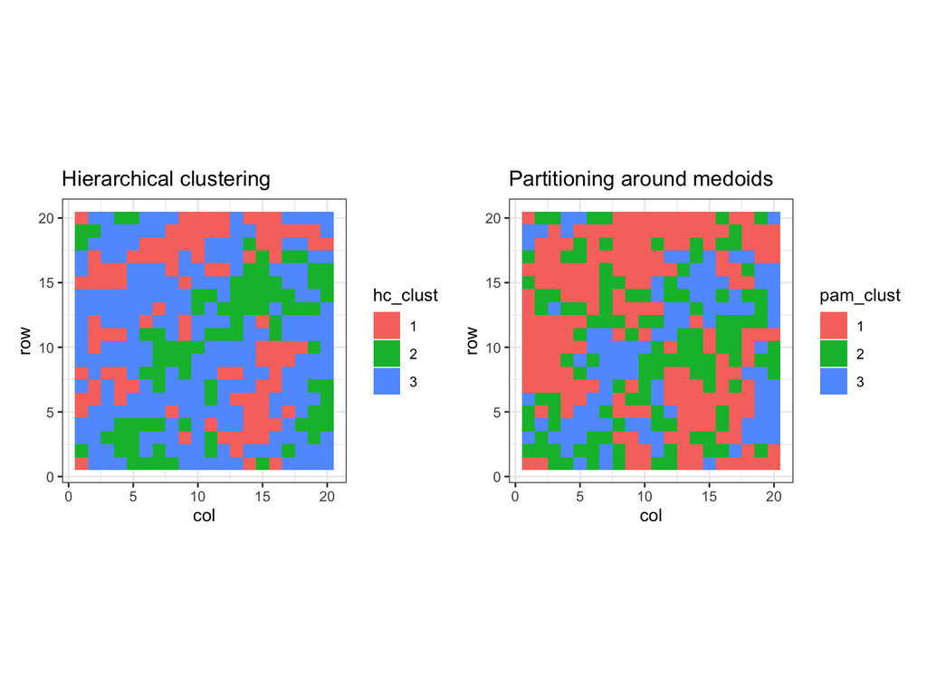

```r
# Create dataframe of clusters per quadrat
clust_df <- data.frame(
  quadrat = names(hc_clust),
  hc_clust = as.character(hc_clust),
  pam_clust = as.character(pam_clust)) %>%
  mutate(
    col = as.numeric(str_sub(quadrat, 1, 2)),
    row = as.numeric(str_sub(quadrat, 3, 4)))

s_clust <- s_ge10 %>%
  left_join(., clust_df, by = c("quadrat", "col", "row"))

hc_clust_tile <- ggplot(clust_df, aes(x = col, y = row, fill = hc_clust)) +
  geom_tile() +
  theme_bw() +
  coord_equal() +
  ggtitle("Hierarchical clustering")

pam_clust_tile <- ggplot(clust_df, aes(x = col, y = row, fill = pam_clust)) +
  geom_tile() +
  theme_bw() +
  coord_equal() +
  ggtitle("Partitioning around medoids")

wrap_plots(hc_clust_tile, pam_clust_tile)
```

Next, we find 100x100 m chunks within the plot that contain a sufficient number of quadrats of a particular habitat type (>= 50%).

```r
# For each habitat type find 1 ha chunks in moving window with >25% quadrats of that type
window_size <- 5  # 100 / 20 = 5
purity_threshold <- 0.5 # At least 50%
habitat_types <- unique(clust_df$pam_clust)

valid_chunks <- data.frame()

min_col <- min(clust_df$col, na.rm = TRUE)
max_col <- max(clust_df$col, na.rm = TRUE)
min_row <- min(clust_df$row, na.rm = TRUE)
max_row <- max(clust_df$row, na.rm = TRUE)

# Safety check: prevent the loop from running backwards if the grid is too narrow
if ((max_col - min_col + 1) >= window_size && (max_row - min_row + 1) >= window_size) {

  # For each habitat type
  for (hab in habitat_types) {
    # For each window position
    for (c in min_col:(max_col - window_size + 1)) {
      for (r in min_row:(max_row - window_size + 1)) {

        window_quads <- subset(clust_df, col >= c & col < (c + window_size) &
          row >= r & row < (r + window_size))

        # Calculate proportion based on pam_clust
        purity <- sum(window_quads$pam_clust == hab, na.rm = TRUE) / (window_size^2)

        if (purity >= purity_threshold) {
          valid_chunks <- rbind(valid_chunks, data.frame(
            pam_clust = hab,
            col_start = c, col_end = c + window_size - 1,
            row_start = r, row_end = r + window_size - 1,
            quadrat_count = sum(window_quads$pam_clust == hab, na.rm = TRUE),
            purity = purity
          ))
        }
      }
    }
  }

  # Sort results by habitat type, then highest purity
  if (nrow(valid_chunks) > 0) {
    valid_chunks <- valid_chunks[order(valid_chunks$pam_clust, -valid_chunks$purity), ]
    rownames(valid_chunks) <- NULL
  }

} else {
  message("Grid is too small for a ", window_size, "x", window_size, " window.")
}

# Add boundary coordinates to the valid_chunks dataframe
valid_chunks$xmin <- valid_chunks$col_start - 0.5
valid_chunks$xmax <- valid_chunks$col_end + 0.5
valid_chunks$ymin <- valid_chunks$row_start - 0.5
valid_chunks$ymax <- valid_chunks$row_end + 0.5
quadrat_size <- 20
valid_chunks$xmin_m <- (valid_chunks$col_start - 1) * quadrat_size
valid_chunks$xmax_m <- valid_chunks$col_end * quadrat_size
valid_chunks$ymin_m <- (valid_chunks$row_start - 1) * quadrat_size
valid_chunks$ymax_m <- valid_chunks$row_end * quadrat_size
valid_chunks$chunk_id <- 1:nrow(valid_chunks)
```

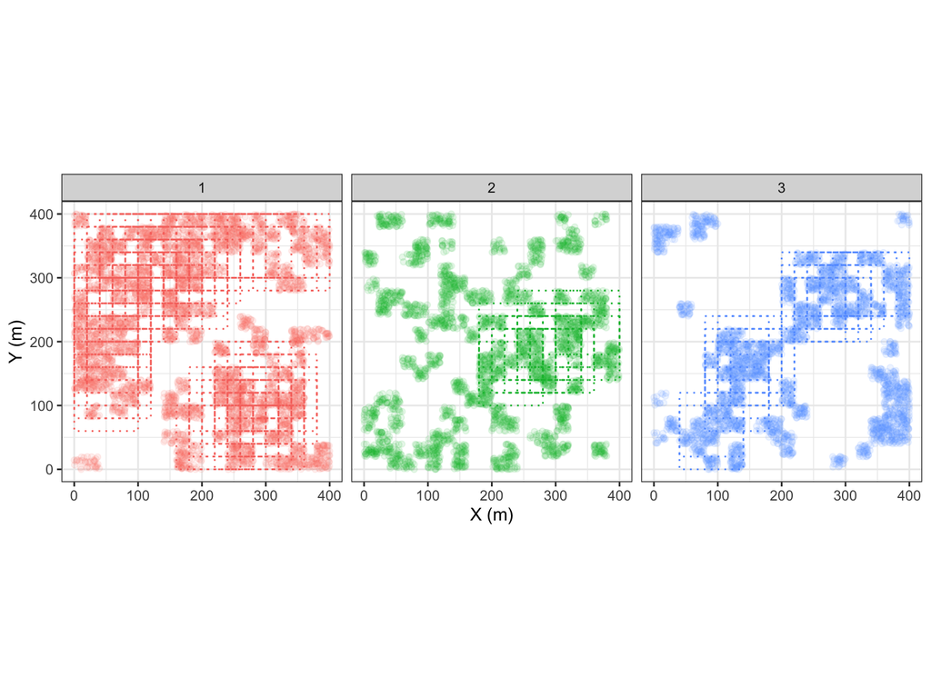

```r
# Plot the distribution of valid chunks for each habitat type
ggplot(s_clust, aes(x = x, y = y)) +
  geom_point(aes(colour = pam_clust), alpha = 0.1) +
  geom_rect(data = valid_chunks,
    inherit.aes = FALSE,
    aes(
      xmin = xmin_m, xmax = xmax_m,
      ymin = ymin_m, ymax = ymax_m,
      colour = as.character(pam_clust)),
    fill = NA, linetype = "dotted") +
  facet_wrap(~pam_clust) +
  theme_bw() +
  theme(legend.position = "none") +
  coord_equal() +
  labs(colour = "Habitat Type", x = "X (m)", y = "Y (m)")
```

```r
# Define stem diameter quantile threshold
q <- 1

# Calculate 95th percentile of stem diameter for each valid chunk
valid_chunks$diam_q <- sapply(seq_len(nrow(valid_chunks)), function(i) {
  c_start <- valid_chunks$col_start[i]
  c_end   <- valid_chunks$col_end[i]
  r_start <- valid_chunks$row_start[i]
  r_end   <- valid_chunks$row_end[i]

  # Filter stems that fall inside 5x5 chunk
  chunk_stems <- subset(s_ge10, col >= c_start & col <= c_end & row >= r_start & row <= r_end)

  if (nrow(chunk_stems) > 0) {
    # return(quantile(chunk_stems$diam, probs = q, na.rm = TRUE, names = FALSE))
    return(max(chunk_stems$diam, na.rm = TRUE))
  } else {
    return(0)
  }
})

# Sort chunks by largest tree diameter descending.
# If there is a tie in tree size, use purity, then a random value
valid_chunks$random_tiebreaker <- runif(nrow(valid_chunks))
valid_chunks_sorted <- valid_chunks[
  order(
    -valid_chunks$diam_q,
    -valid_chunks$purity,
    valid_chunks$random_tiebreaker), ]

# Greedy selection to ensure selected 100x100 m chunks do not overlap
selected_chunks <- data.frame()
habitats_needed <- unique(valid_chunks_sorted$pam_clust)

# Helper function: Returns TRUE if two chunks overlap
check_overlap <- function(box1, box2) {
  overlap_col <- (box1$col_start <= box2$col_end) && (box1$col_end >= box2$col_start)
  overlap_row <- (box1$row_start <= box2$row_end) && (box1$row_end >= box2$row_start)
  return(overlap_col && overlap_row)
}

# Iterate through the sorted list and select the best non-overlapping chunks
for (i in 1:nrow(valid_chunks_sorted)) {
  candidate <- valid_chunks_sorted[i, ]

  # Skip if already selected a plot for this habitat type
  if (candidate$pam_clust %in% selected_chunks$pam_clust) { next }

  # Check if the candidate overlaps with any chunks already selected
  overlaps <- FALSE
  if (nrow(selected_chunks) > 0) {
    for (j in 1:nrow(selected_chunks)) {
      if (check_overlap(candidate, selected_chunks[j, ])) {
        overlaps <- TRUE
        break
      }
    }
  }

  # Otherwise, select the chunk
  if (!overlaps) {
    selected_chunks <- rbind(selected_chunks, candidate)
  }

  # Stop early if all habitat types have a plot
  if (nrow(selected_chunks) == length(habitats_needed)) {
    break
  }
}
```

Finally plot out the chosen plots along with the original stem data:

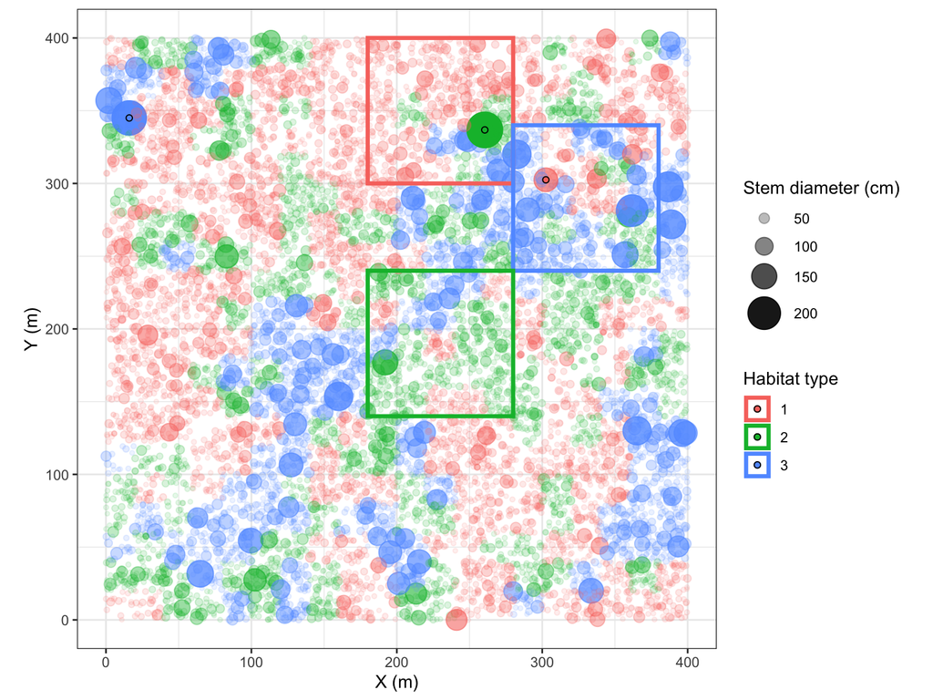

```r
s_biggest <- s_clust %>%
  group_by(pam_clust) %>%
  filter(diam == max(diam))

# Plot the chosen quadrats with the original stem data
ggplot(s_clust, aes(x = x, y = y)) +
  geom_point(aes(colour = as.character(pam_clust), size = diam, alpha = diam)) +
  geom_rect(data = selected_chunks,
            inherit.aes = FALSE,
            aes(xmin = xmin_m, xmax = xmax_m,
                ymin = ymin_m, ymax = ymax_m,
                colour = as.character(pam_clust)),
            fill = NA,
            linewidth = 1.2,
            linetype = "solid") + # Switched to solid to signify final selection
  geom_point(data = s_biggest,
    aes(x = x, y = y, fill = pam_clust),
    shape = 21, colour = "black") +
  scale_fill_discrete(name = "Habitat type") +
  scale_colour_discrete(name = "Habitat type") +
  scale_radius(name = "Stem diameter (cm)", range = c(1, 10)) +
  scale_alpha(name = "Stem diameter (cm)", range = c(0.1, 1)) +
  theme_bw() +
  coord_equal() +
  labs(x = "X (m)", y = "Y (m)")
```